# Regression Models

Insight: If there was a hypothetical variable that contributed a great deal to the model fit, which was unknown to us, the error terms using the other two variables would look like random scatter. Wouldn’t it?

Let’s simulate the data generation process. This would give me a great deal of insights. The easiest thing to do would be to reverse-engineer a linear model.

```r
library(tidyverse)
```

```r
x1 <- rnorm(20, 50, 10)
x2 <- rnorm(20, 50, 10)

b0 <- 50
b1 <- 50
b2 <- 50
# sigma <- 0

eps <- 0

y <- b0 + b1*x1 + b2*x2
```

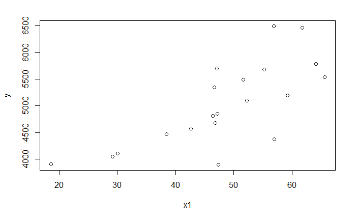

```r
plot(y ~ x1)
```

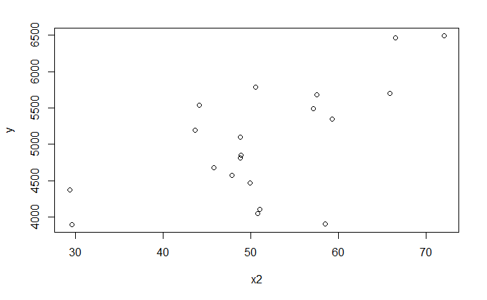

```r
plot(y ~ x2)
```

```r
model <- lm(y ~ x2)
```

```r
summary(model)
```

[output not shown]

[output not shown]

[figure not shown]

It shows that all of this variation can be explained by mathematical formulas.

```r
sample(y, 10)
```

```
 [1] 5345.593 4678.101 3896.574 5786.085 6497.541 6463.813 4047.316 3901.668 5102.840 4105.645
```

When you have no preconceptions on the data generation process, this just looks like random noise. You can however also look at the shape of the distribution. This by itself doesn’t assume anything about how the data is generated.

This is the equivalent of measuring heights or school performances of children. We can note: Interesting, but what causes some children to perform well and other children to perform worse?

We need **predictors** of academic performance. How do we go about obtaining those? Well, we could measure other characteristics of each child and see if something changes along with performance, in other words, is correlated with the performance. I’m using correlation broadly, there is not necessarily only linear correlation, there are many other shapes of correlation.

We measure their IQ for example and plot the results. We see that there is a linear relation, with plenty of scatter around the trendline. We could look at a model and conclude what proportion of variance is explained by IQ. This is a very robust method for showing predictor - effect relationships.

This classical statistics approach fails only when the underlying data generation process is very complicated and we fail to find variables that easily explain the variation of the dependent variable with any reasonable certainty.

In this case, a machine learning approach might be warranted if our only goal is to predict a variable. The issue is that the models can get very complicated and the underlying relationship will not be interpretable to us humans. This is not necessarily an issue. It has a profound indication that we are not intelligent enough as humans to perceive a multitude of complicated relationships within the data, the data generation process remains a mystery.

In this sense, what machine learning does is help transcend our limitations as humans and extend our abilities. It is transcending the limitations of our brains.